# ✈️ Flight4u – Intelligent Flight Search Application

## 🎯 Project Goal

**Flight4u** is an application that helps users find the most suitable flight offers based on their preferences. Data can be input via voice or text. The app transforms natural language input into filtering and sorting parameters and matches flight offers in real time.

## 🧰 Technologies and Tools

| Category | Technology | Purpose |
| --- | --- | --- |
| UI | `streamlit` | User interface |
| Voice | `Whisper`, `audiorecorder` | Handling audio recordings |
| AI | `OpenAI GPT-4o` | Semantic processing |
| Embeddings | `text-embedding-3-large` | Creating preference vectors |
| Vector Database | `Qdrant` | Vector-based database |
| Processing | `pandas`, `datetime`, `re` | Flight filtering and analysis |

## 🧠 Converting Preferences and Adding to Database

Before user data can be processed by the app, the text must be:

- transformed into a vector embedding (semantic representation),
- numerically encoded for filtering (e.g., climate → number),
- stored in the Qdrant vector database as a new point.

```
# Create text embedding
def user_text_to_embedings(text):
    response = openai_client.embeddings.create(
        model="text-embedding-3-large",
        input=text,
        dimensions=1536
    )
    return response.data[0].embedding

# Add embedding + text to Qdrant database
def add_note_to_db(text_to_emb, text_to_db):
    qdrant_client = QdrantClient(
        url=env["QDRANT_URL"],
        api_key=env["QDRANT_API_KEY"]
    )

    points_count = qdrant_client.count(
        collection_name=QDRANT_COLLECTION_NAME,
        exact=True,
    )

    qdrant_client.upsert(
        collection_name=QDRANT_COLLECTION_NAME,
        points=[
            PointStruct(
                id=points_count.count + 1,
                vector=user_text_to_embedings(text_to_emb),
                payload=text_to_db
            )
        ]
    )
```

## 📥 Data Input in the App

Users can:

- type their preferences (e.g., “Looking for a warm vacation in July, max $2000”)
- use the voice recording button 🎤

📸 **UI screenshot of preference input:**

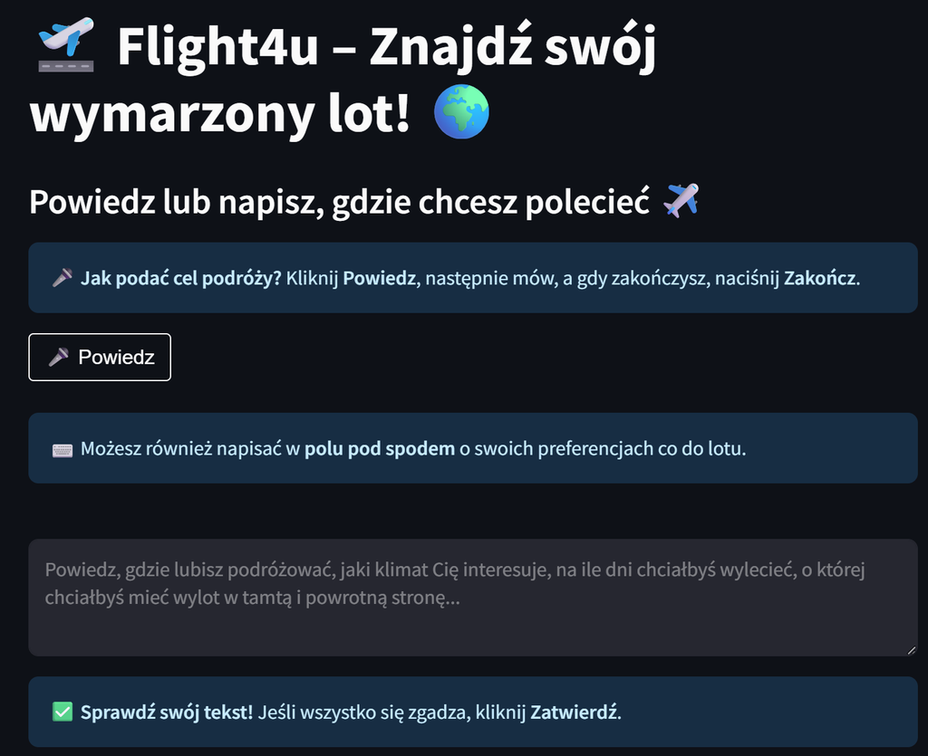

## 🔢 Converting User Data into Numerical Values

Some user input (e.g., climate, continent, season, time of day) is converted into numerical values to allow comparison and processing in filtering algorithms.

**Example: Converting continents into numbers:**

```
def classify_continent_number(time_of_flight_and_arrival):
    if time_of_flight_and_arrival == "Europe":
        return 0
    elif time_of_flight_and_arrival == "Africa":
        return 5
    elif time_of_flight_and_arrival == "Asia":
        return 10
    elif time_of_flight_and_arrival == "North America":
        return 15
    else:
        return 20
```

## 🗃️ Retrieving Data from the Vector Database

Based on the user query (text or voice), an embedding is created and the most relevant flight options are retrieved from the Qdrant database.

**Function for retrieving from the database:**

```
def flights_from_db(query):
    flights = qdrant_client.search(
        collection_name=QDRANT_COLLECTION_NAME,
        query_vector=user_text_to_embedings(query),
        limit=400,
    )
    result = []
    for flight in flights:
        result.append({
            "destination": flight.payload["destination"],
            "continent_of_destination": flight.payload["continent_of_destination"],
            "classify_continent_number": flight.payload["classify_continent_number"],
            "temperature_of_destination": flight.payload["temperature_of_destination"],
            "classify_climat_number": flight.payload["classify_climat_number"],
            "cost_of_both_flights": flight.payload["cost_of_both_flights"],
            "amount_of_days_vacation": int(flight.payload["amount_of_days_vacation"]),
            "categorized_dep_time_poland": flight.payload["categorized_dep_time_poland"],
            "categorized_dep_time_poland_number": flight.payload["categorized_dep_time_poland_number"],
            "categorized_dep_time_abroad": flight.payload["categorized_dep_time_abroad"],
            "categorized_dep_time_abroad_number": flight.payload["categorized_dep_time_abroad_number"],
            "when_flight": flight.payload["time_of_flight_and_arrival"],
            "when_flight_number": flight.payload["amount_of_days_when_flight_number"],
            "season_of_flight": flight.payload["season_of_departure"],
            "season_of_flight_number": flight.payload["season_of_departure_number"],
            "month_of_flight": flight.payload["month_of_flight"],
            "month_of_flight_number": flight.payload["month_of_flight_number"],
            "score": flight.score,
        })
    result_df = pd.DataFrame(result)
    return result_df
```

## 🧠 Filtering Results Based on User Preferences

After selecting the 400 most similar results via embeddings, the app filters these using additional user preferences (climate, budget, time of day, vacation duration) to find the best matches.

### 🔍 How Does Filtering Work?

In each category (e.g., **climate, continent, vacation length, flight time**):

1. User preferences are converted to numerical values.
2. For each offer, the difference between the user's value and the offer’s value is calculated.
3. The absolute value of this difference is computed.
4. All differences are summed and stored in the `preference_score` column.
5. The data is sorted ascendingly by `preference_score`.

💡 The **lower the `preference_score`**, the **better the match**.

### 📦 Example of Matching Algorithm

User input:

> "I want to go on vacation to a warm country in July, preferably in the morning, for around 7 days, max $2000"

The app:

- Creates an embedding and selects the **400** most similar records.
- Then checks each offer:

| Category | User Preference | Offer Value | Absolute Difference |
| --- | --- | --- | --- |
| Climate | 10 (warm) | 8 (very warm) | `abs(10 - 8) = 2` |
| Departure Time (PL) | 0 (morning) | 3 (afternoon) | `abs(0 - 3) = 3` |
| Budget | ≤ $2000 | $1950 | ✅ within limit |
| Vacation Duration | 7 days | 6 days | `abs(7 - 6) = 1` |

- Total `preference_score` = **2 + 3 + 1 = 6**
- Offers with **lowest scores** appear at the top.

### 📈 Visual Output

After identifying the best-matching offers, the application presents them clearly and attractively in the user interface using Streamlit’s HTML component.

📸 Screenshot of an offer presentation:

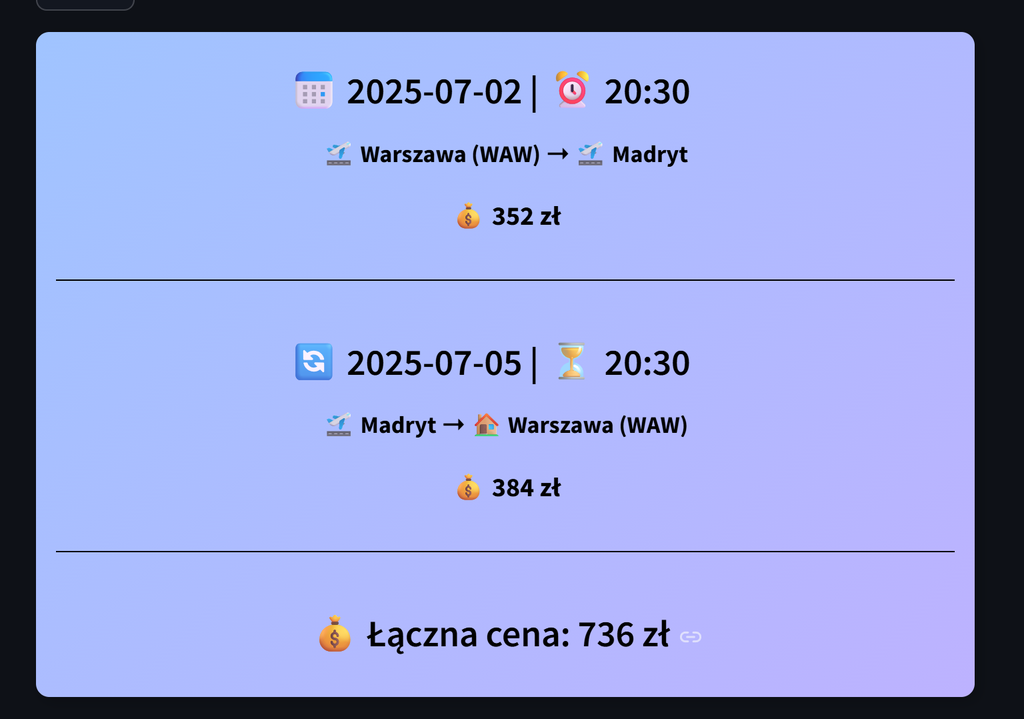

## 🚀 Potential App Improvements

While the application already works efficiently, several enhancements could improve its functionality:

- **🔍 Multi-criteria search** – allow users to prioritize (e.g., "climate is more important than price").
- **📅 Real-time availability checks** – integrate with airline APIs to show only live offers.
- **📊 Comparative visualizations** – interactive charts comparing prices, durations, and weather.

💡 With these upgrades, the app could become even smarter, more useful, and competitive in the travel market! '''